# Trump World

Felipe Riva

## Introduzione

Nessun presidente americano è mai entrato in carica con una gigantesca rete di imprese, investimenti e connessioni aziendali come quella accumulata da Donald J. Trump. La sua famiglia e i suoi consulenti hanno toccato un numero incredibile di imprese, da un hotel in Azerbaigian a una società di poker a Las Vegas.

John Templon, Anthony Cormier, Alex Campbell e Jeremy Singer-Vine hanno creato un dataset da registri pubblici, notizie e altre fonti sulla famiglia Trump.

Il dataset è formato da persone e organizzazioni legate al 45° Presidente degli Stati Uniti, Donald J Trump.

Queste persone e organizzazioni formano una rete della quale sono i nodi e gli archi sono associazioni tra queste.

Ogni riga del dataset rappresenta una connessione o tra una persona e una organizzazione o tra una persona ed un’altra persona oppure tra due organizzazioni.

Il dataset si può scaricare dal sito: [ICON](https://icon.colorado.edu/#!/)

Le informazioni sui creatori e l’articolo in cui viene citato il dataset si trovano qui: [BuzzFeedNews Trump World](https://www.buzzfeednews.com/article/johntemplon/help-us-map-trumpworld)

In seguito cercherò di ricavare qualche informazione da questa rete di associazioni.

## Read Dataset

```r
library(readr)

TrumpWorld = read_csv("TrumpWorld.csv")

TrumpWorld
```

```
## # A tibble: 3,380 x 6
##    `Entity A Type` `Entity A`  `Entity B Type` `Entity B` Connection `Source(s)`
##    <chr>           <chr>       <chr>           <chr>      <chr>      <chr>
##  1 Organization    4 SHADOW T~ Organization    4 SHADOW ~ Ownership  https://ww~
##  2 Organization    40 WALL DE~ Organization    40 WALL S~ Ownership  https://ww~
##  3 Organization    40 WALL ST~ Organization    40 WALL S~ Ownership  https://ww~
##  4 Organization    40 WALL ST~ Organization    40 WALL S~ Ownership  https://ww~
##  5 Organization    401 MEZZ V~ Organization    401 NORTH~ Ownership  https://ww~
##  6 Organization    401 MEZZ V~ Organization    TRUMP CHI~ Ownership  https://ww~
##  7 Organization    401 NORTH ~ Organization    TRUMP COM~ Ownership  https://ww~
##  8 Organization    401 NORTH ~ Organization    TRUMP PAY~ Ownership  https://ww~
##  9 Organization    4C INSIGHTS Person          JEREMY KA~ Former ad~ https://ww~
## 10 Organization    809 NORTH ~ Organization    809 NORTH~ Ownership  https://ww~
## # ... with 3,370 more rows
```

```r
library(dplyr)
edges = TrumpWorld%>%
  select(`Entity A`, `Entity B`, Connection)%>%
  rename(from = 'Entity A', to = 'Entity B')
edges
```

```
## # A tibble: 3,380 x 3
##    from                       to                    Connection
##    <chr>                      <chr>                 <chr>
##  1 4 SHADOW TREE LANE MEMBER~ 4 SHADOW TREE LANE L~ Ownership
##  2 40 WALL DEVELOPMENT ASSOC~ 40 WALL STREET LLC    Ownership
##  3 40 WALL STREET LLC         40 WALL STREET COMME~ Ownership
##  4 40 WALL STREET MEMBER COR~ 40 WALL STREET LLC    Ownership
##  5 401 MEZZ VENTURE LLC       401 NORTH WABASH VEN~ Ownership
##  6 401 MEZZ VENTURE LLC       TRUMP CHICAGO RETAIL~ Ownership
##  7 401 NORTH WABASH VENTURE ~ TRUMP COMMERCIAL CHI~ Ownership
##  8 401 NORTH WABASH VENTURE ~ TRUMP PAYROLL CHICAG~ Ownership
##  9 4C INSIGHTS                JEREMY KATZ           Former advisory council boa~
## 10 809 NORTH CANON MEMBER CO~ 809 NORTH CANON LLC   Ownership
## # ... with 3,370 more rows
```

```r
library(igraph)
library(tidyverse)
g = graph_from_data_frame(edges, directed = FALSE, vertices = NULL)
```

```r
nodes = as.tibble(igraph::as_data_frame(g, what = "vertices"))

entity_a = TrumpWorld%>%
  select(`Entity A`, `Entity A Type`)

entity_b = TrumpWorld%>%
  select(`Entity B`, `Entity B Type`)

entity_a = distinct(left_join(nodes, entity_a, by = c("name" = "Entity A")), name, `Entity A Type`)
entity_b = distinct(left_join(nodes, entity_b, by = c("name" = "Entity B")), name, `Entity B Type`)

nodes = left_join(entity_a, entity_b)%>%
  rename(type_a = `Entity A Type`, type_b = `Entity B Type`)%>%
  mutate(tipo = if_else(!is.na(type_a), type_a, type_b), id = row_number())%>%
  select(id, name, tipo)
nodes
```

```
## # A tibble: 2,669 x 3
##       id name                               tipo
##    <int> <chr>                              <chr>
##  1     1 4 SHADOW TREE LANE MEMBER CORP.    Organization
##  2     2 40 WALL DEVELOPMENT ASSOCIATES LLC Organization
##  3     3 40 WALL STREET LLC                 Organization
##  4     4 40 WALL STREET MEMBER CORP.        Organization
##  5     5 401 MEZZ VENTURE LLC               Organization
##  6     6 401 NORTH WABASH VENTURE LLC       Organization
##  7     7 4C INSIGHTS                        Organization
##  8     8 809 NORTH CANON MEMBER CORPORATION Organization
##  9     9 AARON SCHOCK                       Person
## 10    10 ABDUL WAHID AL ULAMA               Person
## # ... with 2,659 more rows
```

```r
library(tidygraph)
library(ggraph)

trump_graph = tbl_graph(nodes = nodes, edges = edges, directed = FALSE)

trump_graph
```

```
## # A tbl_graph: 2669 nodes and 3380 edges
## #
## # An undirected simple graph with 1 component
## #
## # Node Data: 2,669 x 3 (active)
##      id name                               tipo
##   <int> <chr>                              <chr>
## 1     1 4 SHADOW TREE LANE MEMBER CORP.    Organization
## 2     2 40 WALL DEVELOPMENT ASSOCIATES LLC Organization
## 3     3 40 WALL STREET LLC                 Organization
## 4     4 40 WALL STREET MEMBER CORP.        Organization
## 5     5 401 MEZZ VENTURE LLC               Organization
## 6     6 401 NORTH WABASH VENTURE LLC       Organization
## # ... with 2,663 more rows
## #
## # Edge Data: 3,380 x 3
##    from    to Connection
##   <int> <int> <chr>
## 1     1  1095 Ownership
## 2     2     3 Ownership
## 3     3  1096 Ownership
## # ... with 3,377 more rows
```

## Analyse and Visualize network

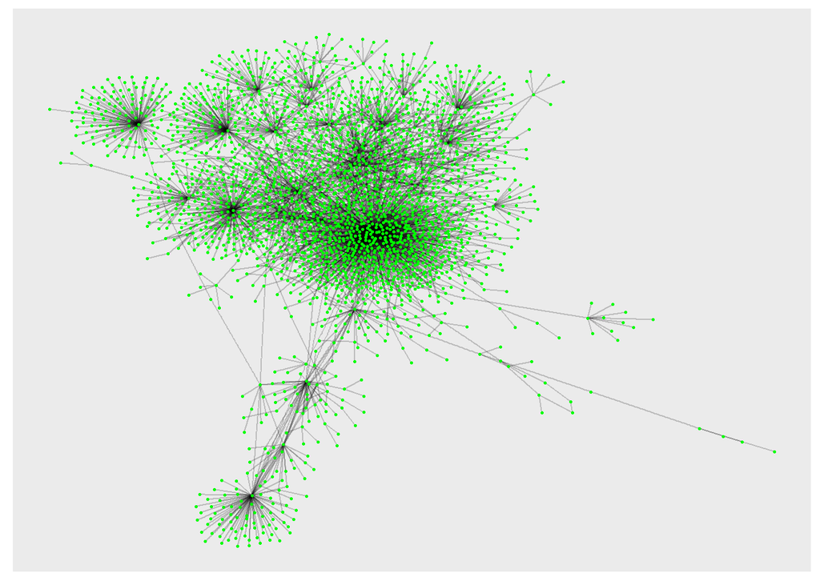

```r
#visualize trump_graph

ggraph(trump_graph, layout = 'lgl')+
  geom_edge_link(alpha=0.2)+
  geom_node_point(alpha=1, size = 0.6, color= "green")
```

Osserviamo la rete differenziando per colore i nodi in base alla variabile **tipo**.

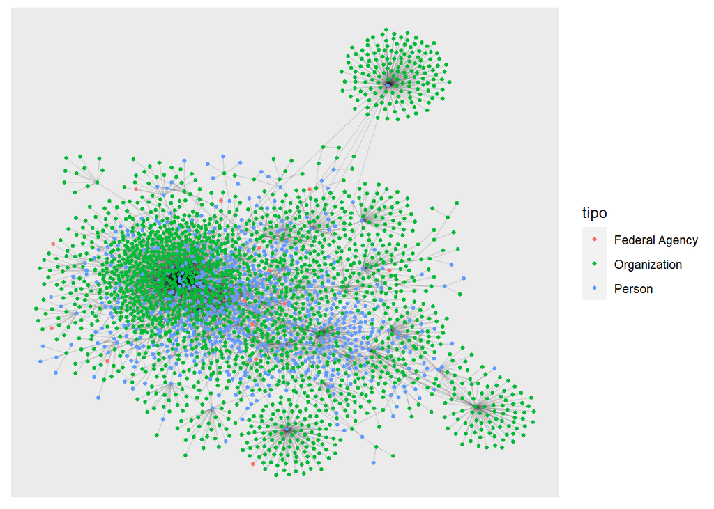

```r
ggraph(trump_graph, layout = 'lgl')+
  geom_edge_link(alpha=0.1)+
  geom_node_point(aes(color=tipo), alpha=1, size=1)
```

Si nota dalla visualizzazione della rete che molti nodi sono organizzazioni e persone, e pochi nodi sono agenzie federali.

Calcoliamo quanti sono in percentuale le organizzazioni, le persone e le agenzie federali.

```r
ties = as.list(trump_graph)$edges
vertices = as.list(trump_graph)$nodes

vertices%>%
  group_by(tipo)%>%
  summarise(n = n())%>%
  mutate(percentage = round(n / sum(n), 3))
```

```
## # A tibble: 3 x 3
##   tipo               n percentage
##   <chr>          <int>      <dbl>
## 1 Federal Agency    14      0.005
## 2 Organization    2015      0.755
## 3 Person           640      0.24
```

La maggior parte dei nodi sono organizzazioni.

Facciamo lo stesso per i legami.

```r
ties%>%
  group_by(Connection)%>%
  summarise(n = n())%>%
  mutate(percentage = n / sum(n))%>%
  arrange(desc(percentage))
```

```
## # A tibble: 833 x 3
##    Connection                                                       n percentage
##    <chr>                                                        <int>      <dbl>
##  1 President (as of 2016 FEC filing)                              473     0.140
##  2 Ownership                                                      334     0.0988
##  3 Director                                                       126     0.0373
##  4 Investor                                                       120     0.0355
##  5 Reported member                                                103     0.0305
##  6 Former director                                                 66     0.0195
##  7 Listed as asset/income on Public Financial Disclosure Report    63     0.0186
##  8 Member                                                          60     0.0178
##  9 Subsidiary                                                      55     0.0163
## 10 Owns collateralized debt                                        54     0.0160
## # ... with 823 more rows
```

Notiamo che ci sono più di 800 tipologie di legami e che quelli più ricorrenti sono President, Ownership e Director.

Quanti sono i legami tra due organizzazioni, tra due persone e tra organizzazione e persona?

```r
# tolgo i nodi che sono agenzie federali
withoutFA = vertices%>%
  filter(tipo != "Federal Agency")

ties%>%
  left_join(withoutFA, by = c("from" = "id"))%>%
  left_join(withoutFA, by = c("to" = "id"))%>%
  select(from, to, tipo.x, tipo.y)%>%
  # tolgo le righe con valori NA che erano legami delle agenzie federali
  filter(!is.na(tipo.x), !is.na(tipo.y))%>%
  mutate(org_org = if_else(tipo.x == "Organization" & tipo.y == "Organization", TRUE, FALSE),
         pers_pers = if_else(tipo.x == "Person" & tipo.y == "Person", TRUE, FALSE),
         org_pers = if_else((tipo.x == "Person" & tipo.y == "Organization") | (tipo.x == "Organization" &
                                                                               tipo.y == "Person"), T, F))%>%
  group_by(org_org, pers_pers, org_pers)%>%
  summarise(n = n())
```

```
## # A tibble: 3 x 4
## # Groups:   org_org, pers_pers [3]
##   org_org pers_pers org_pers     n
##   <lgl>   <lgl>     <lgl>    <int>
## 1 FALSE   FALSE     TRUE      2199
## 2 FALSE   TRUE      FALSE      381
## 3 TRUE    FALSE     FALSE      782
```

Con quale tipo di nodi Donald Trump ha più collegamenti?

```r
edges%>%
  filter((from=="DONALD J. TRUMP")|(to=="DONALD J. TRUMP"))%>%
  mutate(name= ifelse(from=="DONALD J. TRUMP", to, ifelse(to=="DONALD J. TRUMP", from, NA)))%>%
  select(name)%>%
  inner_join(nodes)%>%
  group_by(tipo)%>%
  summarise(n = n())
```

```
## # A tibble: 2 x 2
##   tipo             n
##   <chr>        <int>
## 1 Organization   574
## 2 Person         183
```

Donald Trump è collegato con 574 organizzazioni e 183 persone.

Che tipo di collegamento ha con le organizzazioni?

```r
edges%>%
  filter((from=="DONALD J. TRUMP")|(to=="DONALD J. TRUMP"))%>%
  mutate(name= ifelse(from=="DONALD J. TRUMP", to, ifelse(to=="DONALD J. TRUMP", from, NA)))%>%
  inner_join(nodes, by = c("name" = "name"))%>%
  select(name, tipo, Connection)%>%
  filter(tipo=="Organization")%>%
  group_by(Connection)%>%
  summarise(n = n())%>%
  arrange(desc(n))
```

```
## # A tibble: 32 x 2
##    Connection                            n
##    <chr>                             <int>
##  1 President (as of 2016 FEC filing)   473
##  2 Member (as of 2016 FEC filing)       27
##  3 Partner (as of 2016 FEC filing)      13
##  4 Trustee (as of 2016 FEC filing)       9
##  5 Chairman (as of 2016 FEC filing)      6
##  6 Director (as of 2016 FEC filing)      5
##  7 Business partner                      3
##  8 Former member and president           3
##  9 Former owner                          3
## 10 Former president                      3
## # ... with 22 more rows
```

Trump ha con 473 organizzazioni, delle 574 con cui è collegato, un collegamento di tipo President, cioè ne è il presidente.

Che tipo di collegamento ha con le persone?

```r
edges%>%
  filter((from=="DONALD J. TRUMP")|(to=="DONALD J. TRUMP"))%>%
  mutate(name= ifelse(from=="DONALD J. TRUMP", to, ifelse(to=="DONALD J. TRUMP", from, NA)))%>%
  inner_join(nodes, by = c("name" = "name"))%>%
  select(name, tipo, Connection)%>%
  filter(tipo=="Person")%>%
  group_by(Connection)%>%
  summarise(n = n())%>%
  arrange(desc(n))
```

```
## # A tibble: 140 x 2
##    Connection                                                                  n
##    <chr>                                                                   <int>
##  1 "Special assistant"                                                        16
##  2 "Deputy assistant"                                                          9
##  3 "Member of Trump's Strategic and Policy forum"                              6
##  4 "\"Leader\" in the transition team per CNN"                                 4
##  5 "A top touchstone outside the White House, according to the New York T~     3
##  6 "Parent/child"                                                              3
##  7 "Advisor for policy, strategy, and speechwriting"                           2
##  8 "Business partners"                                                         2
##  9 "Deputy communications director"                                            2
## 10 "Former campaign manager"                                                   2
## # ... with 130 more rows
```

Quali sono le 473 organizzazioni delle quali Trump è presidente?

```r
president_org=edges%>%
  filter((from=="DONALD J. TRUMP")|(to=="DONALD J. TRUMP"))%>%
  mutate(name= ifelse(from=="DONALD J. TRUMP", to, ifelse(to=="DONALD J. TRUMP", from, NA)))%>%
  inner_join(nodes, by = c("name" = "name"))%>%
  select(name, tipo, Connection)%>%
  filter(tipo=="Organization")%>%
  filter(Connection=="President (as of 2016 FEC filing)")
president_org
```

```
## # A tibble: 473 x 3
##    name                              tipo        Connection
##    <chr>                             <chr>       <chr>
##  1 3126 CORPORATION                  Organizati~ President (as of 2016 FEC fili~
##  2 4 SHADOW TREE LANE LLC            Organizati~ President (as of 2016 FEC fili~
##  3 4 SHADOW TREE LANE MEMBER CORP.   Organizati~ President (as of 2016 FEC fili~
##  4 40 WALL DEVELOPMENT ASSOCIATES L~ Organizati~ President (as of 2016 FEC fili~
##  5 40 WALL STREET COMMERCIAL LLC     Organizati~ President (as of 2016 FEC fili~
##  6 40 WALL STREET LLC                Organizati~ President (as of 2016 FEC fili~
##  7 40 WALL STREET MEMBER CORP.       Organizati~ President (as of 2016 FEC fili~
##  8 401 MEZZ VENTURE LLC              Organizati~ President (as of 2016 FEC fili~
##  9 401 NORTH WABASH VENTURE LLC      Organizati~ President (as of 2016 FEC fili~
## 10 55 WALL DEVELOPMENT CORP.         Organizati~ President (as of 2016 FEC fili~
## # ... with 463 more rows
```

Tracciamo il grafo con solo le connesioni delle organizzazioni delle quali Trump è presidente.

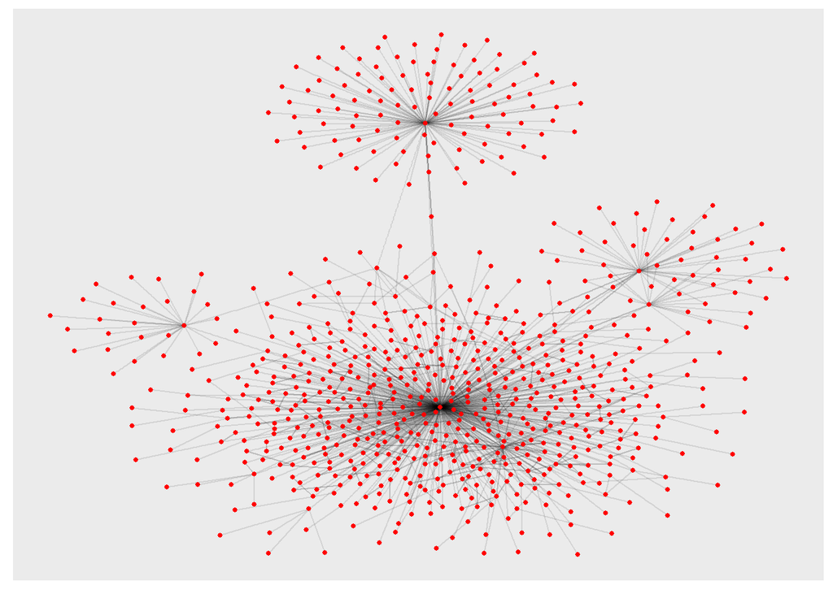

```r
# collegamenti in cui in from ci sono le organizzazioni di trump
president_org_from=president_org%>%
  select(name)%>%
  left_join(edges, by=c("name"="from"))%>%
  filter(!is.na(to))%>%
  rename(from=name)%>%
  select(-Connection)

# collegamenti in cui in to ci sono le organizzazioni di trump
president_org_to=president_org%>%
  select(name)%>%
  left_join(edges, by=c("name"="to"))%>%
  filter(!is.na(from))%>%
  rename(to=name)%>%
  select(from, to)

# unisco i due dataframe
pres_org_connections = rbind(president_org_from, president_org_to)

G = graph_from_data_frame(pres_org_connections, directed = F)

ggraph(G, layout = "lgl")+
  geom_edge_link(alpha=0.1)+
  geom_node_point(size=1, color="red")
```

## Misure di Centralità

Quali sono i nodi più centrali/importanti nella rete?

Iniziamo col visualizzare i nodi con la degree centrality più alta.

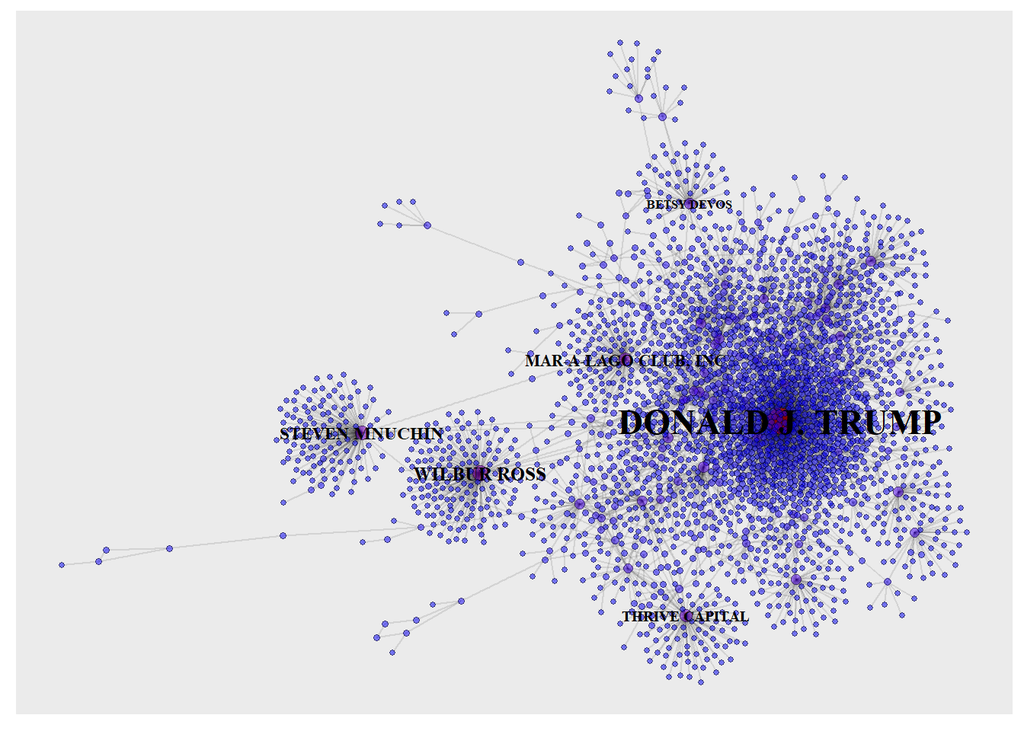

```r
ggraph(trump_graph, layout = "lgl")+
  geom_edge_link(alpha = 0.1)+
  geom_node_point(aes(fill=centrality_degree(), size = centrality_degree()),
                  show.legend=FALSE, alpha = 0.5, shape=21)+
  geom_node_text(aes(filter = centrality_degree() > 50, label = name,
                     size= centrality_degree()), family="serif", fontface= "bold", show.legend = FALSE)+
  scale_fill_continuous(low = "blue", high= "red")
```

Visualizziamo anche i nodi con la closeness centrality più bassa, cioè quei nodi che stanno nella zona periferica della rete.

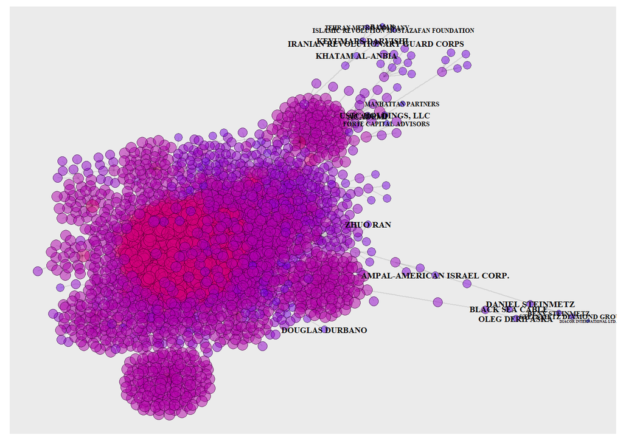

```r
ggraph(trump_graph, layout = "lgl")+
  geom_edge_link(alpha = 0.1)+
  geom_node_point(aes(fill=centrality_closeness(), size = centrality_closeness()),
                  show.legend=FALSE, alpha = 0.5, shape=21)+
  geom_node_text(aes(filter = centrality_closeness() < 0.00006, label = name,
                     size= centrality_closeness()), family="serif", fontface= "bold",
                 show.legend = FALSE)+
  scale_fill_continuous(low = "blue", high= "red")
```

Calcoliamo la degree, betweenness, closeness e PageRank centrality per analizzare quali sono e di che tipo sono i nodi più centrali.

```r
centralities = trump_graph%>%
  activate(nodes)%>%
  mutate(degree = centrality_degree(),
         betweenness = centrality_betweenness(),
         closeness = centrality_closeness(),
         pagerank = centrality_pagerank())

as.list(centralities)$nodes%>%
  arrange(desc(degree))%>%
  head(5)
```

```
## # A tibble: 5 x 7
##      id name                 tipo         degree betweenness closeness pagerank
##   <int> <chr>                <chr>         <dbl>       <dbl>     <dbl>    <dbl>
## 1   211 DONALD J. TRUMP      Person          757    3347190.  0.000193   0.0903
## 2  1075 WILBUR ROSS          Person          157     403444.  0.000133   0.0264
## 3   775 STEVEN MNUCHIN       Person          118     306885.  0.000132   0.0195
## 4   529 MAR-A-LAGO CLUB, INC Organization    110     280661.  0.000132   0.0174
## 5   857 THRIVE CAPITAL       Organization     87     202078.  0.000101   0.0129
```

```r
as.list(centralities)$nodes%>%
  arrange(desc(betweenness))%>%
  head(5)
```

```
## # A tibble: 5 x 7
##      id name                 tipo         degree betweenness closeness pagerank
##   <int> <chr>                <chr>         <dbl>       <dbl>     <dbl>    <dbl>
## 1   211 DONALD J. TRUMP      Person          757    3347190.  0.000193  0.0903
## 2  1075 WILBUR ROSS          Person          157     403444.  0.000133  0.0264
## 3   406 JARED KUSHNER        Person           41     370092.  0.000135  0.00511
## 4   775 STEVEN MNUCHIN       Person          118     306885.  0.000132  0.0195
## 5   529 MAR-A-LAGO CLUB, INC Organization    110     280661.  0.000132  0.0174
```

```r
as.list(centralities)$nodes%>%
  arrange(desc(closeness))%>%
  head(5)
```

```
## # A tibble: 5 x 7
##      id name             tipo   degree betweenness closeness pagerank
##   <int> <chr>            <chr>   <dbl>       <dbl>     <dbl>    <dbl>
## 1   211 DONALD J. TRUMP  Person    757    3347190.  0.000193  0.0903
## 2   406 JARED KUSHNER    Person     41     370092.  0.000135  0.00511
## 3   213 DONALD TRUMP JR. Person     37      74871.  0.000134  0.00402
## 4   388 IVANKA TRUMP     Person     24      75456.  0.000133  0.00248
## 5  1075 WILBUR ROSS      Person    157     403444.  0.000133  0.0264
```

```r
as.list(centralities)$nodes%>%
  arrange(desc(pagerank))%>%
  head(5)
```

```
## # A tibble: 5 x 7
##      id name                 tipo         degree betweenness closeness pagerank
##   <int> <chr>                <chr>         <dbl>       <dbl>     <dbl>    <dbl>
## 1   211 DONALD J. TRUMP      Person          757    3347190.  0.000193   0.0903
## 2  1075 WILBUR ROSS          Person          157     403444.  0.000133   0.0264
## 3   775 STEVEN MNUCHIN       Person          118     306885.  0.000132   0.0195
## 4   529 MAR-A-LAGO CLUB, INC Organization    110     280661.  0.000132   0.0174
## 5   857 THRIVE CAPITAL       Organization     87     202078.  0.000101   0.0129
```

Notiamo che i nodi che ricorrono più spesso nelle top 5 delle quattro misure di centralità, escludendo Trump, sono:

- WILBUR ROSS
- STEVEN MNUCHIN
- JARED KUSHNER
- MAR-A-LAGO CLUB, INC
- THRIVE CAPITAL

e sono tre persone ed due organizzazioni.

Che tipo di legame c’è (se c’è) tra Trump e queste persone/organizzazioni?

```r
edges%>%
  filter(((from == "DONALD J. TRUMP")&(to == "WILBUR ROSS"))|((from == "WILBUR ROSS")&(to == "DONALD J. TRUMP")))
```

```
## # A tibble: 1 x 3
##   from            to          Connection
##   <chr>           <chr>       <chr>
## 1 DONALD J. TRUMP WILBUR ROSS Secretary of Commerce
```

```r
edges%>%
  filter(((from == "DONALD J. TRUMP")&(to == "STEVEN MNUCHIN"))|((from == "STEVEN MNUCHIN")&(to == "DONALD J. TRUMP")))
```

```
## # A tibble: 1 x 3
##   from            to             Connection
##   <chr>           <chr>          <chr>
## 1 DONALD J. TRUMP STEVEN MNUCHIN Secretary of Treasury
```

```r
edges%>%
  filter(((from == "DONALD J. TRUMP")&(to == "JARED KUSHNER"))|((from == "JARED KUSHNER")&(to == "DONALD J. TRUMP")))
```

```
## # A tibble: 1 x 3
##   from            to            Connection
##   <chr>           <chr>         <chr>
## 1 DONALD J. TRUMP JARED KUSHNER Senior adviser
```

```r
edges%>%
  filter(((from == "DONALD J. TRUMP")&(to == "MAR-A-LAGO CLUB, INC"))|((from == "MAR-A-LAGO CLUB, INC")&(to == "DONALD J. TRUMP")))
```

```
## # A tibble: 1 x 3
##   from            to                   Connection
##   <chr>           <chr>                <chr>
## 1 DONALD J. TRUMP MAR-A-LAGO CLUB, INC President (as of 2016 FEC filing)
```

```r
edges%>%
  filter(((from == "DONALD J. TRUMP")&(to == "THRIVE CAPITAL"))|((from == "THRIVE CAPITAL")&(to == "DONALD J. TRUMP")))
```

```
## # A tibble: 0 x 3
## # ... with 3 variables: from <chr>, to <chr>, Connection <chr>
```

Donald Trump non è collegato direttamente all’organizzazione Thrive Capital.

Qual’è la tipologia dei nodi che hanno le misure di centralità più elevate?

```r
as.list(centralities)$nodes%>%
  group_by(tipo)%>%
  summarise(avg_degree = mean(degree),
            avg_bet = mean(betweenness),
            avg_clo = mean(closeness),
            avg_pr = mean(pagerank))
```

```
## # A tibble: 3 x 5
##   tipo           avg_degree avg_bet   avg_clo   avg_pr
##   <chr>               <dbl>   <dbl>     <dbl>    <dbl>
## 1 Federal Agency       1.29    10.2 0.0000957 0.000222
## 2 Organization         1.87  1288.  0.000102  0.000287
## 3 Person               4.65 11629.  0.000101  0.000655
```

Notiamo che i nodi di tipo Person sono quelli con le misure di centralità più alte.

Esiste correlazione tra le quattro misure di centralità?

```r
measures = as.list(centralities)$nodes

M = cbind(degree=measures$degree,
          betweenness = measures$betweenness,
          closeness = measures$closeness,
          pagerank = measures$pagerank)
corM = cor(M, method = "pearson")
corM
```

```
##                degree betweenness closeness  pagerank
## degree      1.0000000   0.9836414 0.1612711 0.9937660
## betweenness 0.9836414   1.0000000 0.1318711 0.9654844
## closeness   0.1612711   0.1318711 1.0000000 0.1575618
## pagerank    0.9937660   0.9654844 0.1575618 1.0000000
```

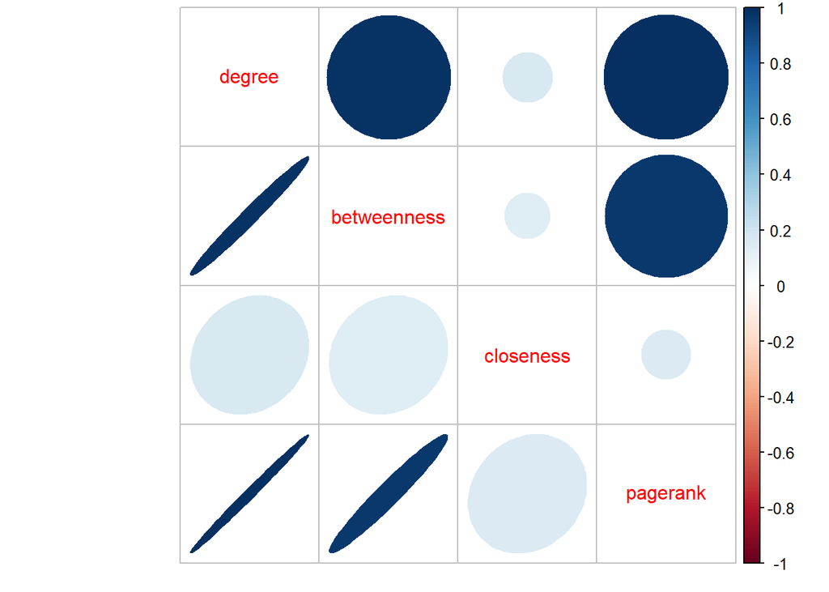

```r
corrplot::corrplot.mixed(corM, lower="ellipse", upper = "circle")
```

La degree centrality e la pagerank centrality hanno un elevata correlazione positiva, cioè i valori delle due misure sono quasi perfettamente allineati su una retta con pendenza positiva. Quindi quando una cresce, cresce anche l’altra.

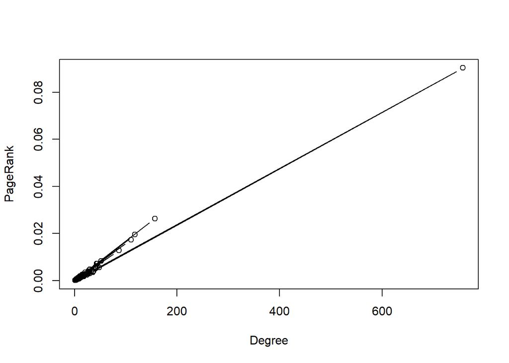

```r
plot(measures$degree, measures$pagerank, type="b", xlab = "Degree", ylab = "PageRank")
```

Invece la betweenness centrality e la closeness centrality hanno una bassa (vicino a zero) correlazione.

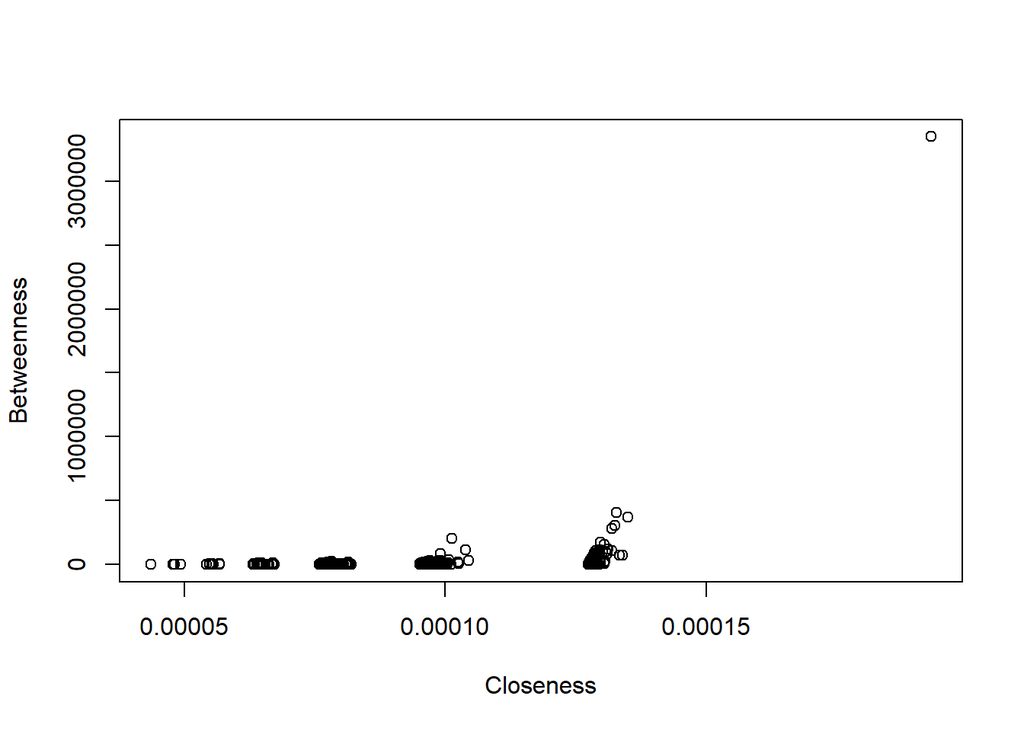

```r
plot(measures$closeness, measures$betweenness, type="p", xlab = "Closeness", ylab="Betweenness")
```

## Power Measures

Analizziamo il potere dei nodi della rete e confrontiamo tale misura di potere con la misura di centralità PageRank Centrality.

In una rete di scambi in cui nei collegamenti si trasferiscono elementi di valore come tempo, denaro, energia o informazioni, la misura di potere dei nodi indica quanto un nodo sia collegato da nodi non potenti. Se un nodo è potente significa che è collegato da molti altri nodi che hanno pochi nodi vicini (opzioni).

```r
library(igraph)
library(lpSolve)

# per trovare il vettore del potere dobbiamo prima accertarci che il grafo sia regolabile ed in caso lo sia,  calcolare il vettore dei pesi di ciascun arco che fan si che il grafo sia regolabile ovvero quando tutti i vertici hanno lo stesso weighted degree

#INPUT :
# g : il grafo
#OUTPUT:
# w : il vettore con i pesi degli archi
# d : il grado di regolarizzazione

regularify = function(g){
  n = vcount(g)
  m = ecount(g)
  E = get.edges(g, E(g))
  B = matrix(0, nrow = n, ncol = m)
  # matrice di incidenza B
  for (i in 1:m) {
    B[E[i,1], i] = 1
    B[E[i,2], i] = 1
  }

  obj = rep(0, m + 1)

  con = cbind(B, rep(-1, n))

  dir = rep("=", n)

  rhs = -degree(g)

  sol = lp("max", obj, con, dir, rhs)

  if (sol$status == 0) {
    s = sol$solution

    w = s[1:m] + 1

    d = s[m+1]
  }

  if(sol$status == 0){
    return(list(weights = w, degree = d))
  }else{
    return(NULL)
  }
}

# se il grafo è regolabile calcoliamo il vettore del potere con il metodo iterativo
#INPUT
# A : matrice di adiacenza del grafo
# t: precisione
#OUTPUT
# vector : power vector
# iter : numero di iterazioni

power = function(A, t) {
  n = dim(A)[1];

  x0 = rep(0, n);

  x1 = rep(1, n);

  x2 = rep(1, n);
  diff = 1
  eps = 1/10^t;
  iter = 0;
  while (diff > eps) {
    x0 = x1;
    x1 = x2;
    x2 = (1/x2) %*% A;
    diff = sum(abs(x2 - x0));
    iter = iter + 1;
  }

  alpha = ((1/x2) %*% A[,1]) / x2[1];

  x2 = sqrt(alpha) %*% x2;
  return(list(vector = as.vector(x2), iter = iter))
}
```

Calcoliamo le misure di potere e di centralità.

```r
from = edges[, "from"]
to = edges[, "to"]
el = cbind(from, to)
g = graph_from_data_frame(el, directed = FALSE)
regularify(g)
```

Il grafo non è regolabile. Dobbiamo perturbare la sua matrice di adiacenza.

```r
A = as_adjacency_matrix(g, sparse = F)
n = vcount(g)
I = diag(0.15, n)
AI = A + I

# calcolo il power vector
p = power(AI, 2)$vector # impiega qualche minuto (dai 10 ai 15 min)
names = nodes$name
names(p) = names

#Calcolo la PageRank Centrality
c = page_rank(g, damping=0.85, personalized = rep(1, vcount(g)))$vector
```

Confronto il potere e la centralità.

```r
# ordino i primi 10 nodi in base alla centralità
round(sort(c, decreasing = TRUE)[1:10], 3)
```

```
##      DONALD J. TRUMP          WILBUR ROSS       STEVEN MNUCHIN
##                0.090                0.026                0.020
## MAR-A-LAGO CLUB, INC       THRIVE CAPITAL          BETSY DEVOS
##                0.017                0.013                0.008
##      REED S. CORDISH        DAVID SHULKIN          ELAINE CHAO
##                0.007                0.007                0.006
##   40 WALL STREET LLC
##                0.006
```

```r
# ordino i primi 10 nodi in base al potere
round(sort(p, decreasing = T)[1:10], 3)
```

```
##      DONALD J. TRUMP          WILBUR ROSS       STEVEN MNUCHIN
##              982.353              375.960              269.622
## MAR-A-LAGO CLUB, INC       THRIVE CAPITAL          BETSY DEVOS
##              249.584              207.706              115.077
##      REED S. CORDISH   40 WALL STREET LLC        DAVID SHULKIN
##              105.987               96.077               94.824
##          ELAINE CHAO
##               94.119
```

```r
# ordino gli ultimi 10 nodi in base alla centralità
round(sort(c, decreasing = F)[1:10], 6)
```

```
##           LUCIUS JOSEPH RICCIO             TTT CONSULTING LLC
##                       0.000143                       0.000144
##           KENNETH CHARLES ROSE IAIN MAURY CAMPBELL MEIKLEJOHN
##                       0.000144                       0.000144
##              JAMES ROBERT WILL               JOHN DELL SAUTER
##                       0.000144                       0.000144
##            KENNETH JOHN MILLAR                 STEWART SELBIE
##                       0.000144                       0.000144
##             ALEXANDER MCMILLAN         CHRISTOPHER JOHN ROUSE
##                       0.000148                       0.000148
```

```r
# ordino gli ultimi 10 nodi in base al potere
round(sort(p, decreasing = F)[1:10], 3)
```

```
##                       ALPHA SIGHTS INC ATLANTIC ACCOUNTABLE CARE ORGANIZATION
##                                  0.347                                  0.347
##                 ATLANTIC HEALTH SYSTEM                            BURNS WHITE
##                                  0.347                                  0.347
##                       CARE NEW ENGLAND                 COLEMAN RESEARCH GROUP
##                                  0.347                                  0.347
## COMMUNITY HOSPITAL ALTERNATIVE FORRISK                       CONTROL RAD, INC
##                                  0.347                                  0.347
##           DATA DRIVEN DELIVERY SYSTEMS           E-HEALTH INTERNATIONAL GROUP
##                                  0.347                                  0.347
```

Si nota che che sia in base alla centralità che in base al potere i primi 10 nodi sono esattamente gli stessi, mentre che per gli ultimi 10 nodi sono completamente diversi.

Esiste correlazione tra le due misure?

```r
cor(c, p, method="pearson")
```

```
## [1] 0.9907106
```

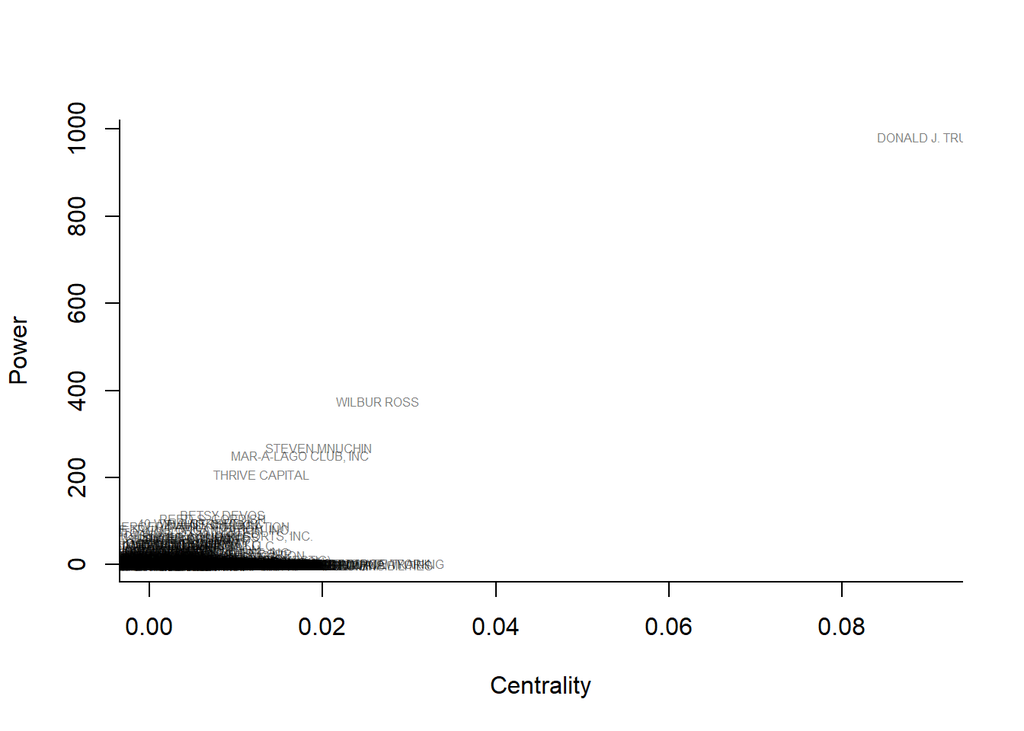

```r
color= rgb(0,0,0,0.5) # nero con opacità 0.5
plot(c, p, xlab="Centrality", pch=NA, ylab="Power", bty="L")
text(c, p, labels = names, cex=0.5, col=color)
```

Si, le due misure sono correlate!

Tracciamo il grafo con la dimensione dei nodi in base al potere per osservare i 5 nodi con il potere più alto che si smarcano da tutti gli altri.

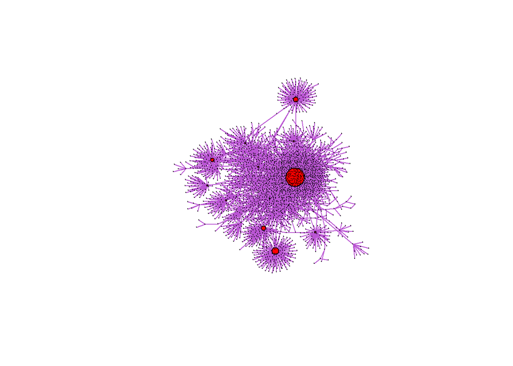

```r
plot(g, layout = layout_with_lgl(g), vertex.size=p/50, vertex.color="red", vertex.label=NA, edge.color="mediumorchid")
```

## Similarity

Analizzare la somiglianza tra i nodi può essere molto utile nell’ambito del **link prediction**, ovvero prevedere le nuove connessioni di un nodo in base alle connessioni dei nodi simili.

Quindi trovando i nodi simili a **Donald Trump** si può sapere:

1. Quali sono i nodi che hanno molti vicini in comune con Donald Trump.
2. Prevedere quali saranno le nuove connessioni di Donald Trump.

Quali sono i nodi simili a Donald Trump?

```r
# ci sono due misure per quantificare la somiglianza tra i nodi, la somiglianza del coseno e la somiglianza con il coefficiente di correlazione di Pearson. Definiamo una funzione che calcola entrambe le misure

similarity = function(g, type = "cosine", mode = "col" ) {
  A = as_adjacency_matrix(g, sparse = FALSE)
  if (mode == "row") {A = t(A)}
  if (type == "cosine") {
    euclidean = function(x) {sqrt(x %*% x)}
    d = apply(A, 2, euclidean)
    D = diag(1/d)
    S = D %*% t(A) %*% A %*% D
  }
  if (type == "pearson") {
    S = cor(A, method = "pearson")
  }
  return(S)
}

library(tidyverse)

g = graph_from_data_frame(edges, directed = FALSE, vertices = nodes$name)

S = similarity(g, type = "cosine")

# annullo la diagonale principale di S poichè sono i valori di autosomiglianza
S = S + diag(-1, nrow(S))

# creo un grafo dalla matrice S in cui gli archi hanno peso uguale alla somiglianza dei nodi che collegano
h = graph_from_adjacency_matrix(S, mode="undirected", weighted = TRUE)

sigma = as.tibble(igraph::as_data_frame(h, what = "edges"))%>%
  rename(x = from, y =to, similarity = weight)%>%
  mutate(x = as.integer(x), y = as.integer(y))%>%
  left_join(nodes, by=c("x"="id"))%>%
  left_join(nodes, by=c("y"="id"))%>%
  select(-tipo.x, -tipo.y)
# i nodi con la somiglianza più alta sono:
head(arrange(sigma, -similarity))
```

```
## # A tibble: 6 x 5
##       x     y similarity name.x                       name.y
##   <int> <int>      <dbl> <chr>                        <chr>
## 1    53   144         1. ANGELA CHAO                  CHRISTINE CHAO
## 2   140   328         1. CHLOE MURDOCH                GRACE MURDOCH
## 3   176   286         1. DANIEL RIDLOFF               FELIX SATER
## 4   865   916         1. TIHT CHICAGO MEMBER ACQUISI~ TRUMP CHICAGO MANAGING ME~
## 5   865   917         1. TIHT CHICAGO MEMBER ACQUISI~ TRUMP CHICAGO MEMBER LLC
## 6   916   917         1. TRUMP CHICAGO MANAGING MEMB~ TRUMP CHICAGO MEMBER LLC
```

I nodi più simili a Donald Trump sono:

```r
head(arrange(filter(sigma, (name.x=="DONALD J. TRUMP")|(name.y=="DONALD J. TRUMP")), -similarity))
```

```
## # A tibble: 6 x 5
##       x     y similarity name.x            name.y
##   <int> <int>      <dbl> <chr>             <chr>
## 1   207   211      0.170 DJT HOLDINGS LLC  DONALD J. TRUMP
## 2   211   212      0.140 DONALD J. TRUMP   DONALD J. TRUMP FOR PRESIDENT, INC.
## 3   211   276      0.129 DONALD J. TRUMP   ERIC TRUMP
## 4   211  1036      0.109 DONALD J. TRUMP   TTTT VENTURE LLC
## 5   211   213      0.108 DONALD J. TRUMP   DONALD TRUMP JR.
## 6    29   211      0.105 ALLEN WEISSELBERG DONALD J. TRUMP
```

- DJT HOLDINGS LLC
- DONALD J. TRUMP FOR PRESIDENT, INC.
- ERIC TRUMP
- TTTT VENTURE LLC
- DONALD TRUMP JR.
- ALLEN WEISSELBERG

Ora che conosciamo i nodi più simili a Trump, cerchiamo di prevedere quali potranno essere le sue nuove connessioni.

Seleziono i vicini dei 5 nodi più simili a Donald Trump.

```r
top_5 = sigma%>%
  filter((name.x=="DONALD J. TRUMP")|(name.y=="DONALD J. TRUMP"))%>%
  arrange(desc(similarity))%>%
  select(name.x, name.y)%>%
  head(5)

top_5 = stack(top_5)%>%
  select(values)%>%
  filter(values != "DONALD J. TRUMP")%>%
  rename(name = values)

neighbors_1= top_5%>%
  left_join(edges, by=c("name" = "from"))

neighbors_2 = top_5%>%
  left_join(edges, by=c("name" = "to"))

top_neighbors = c(neighbors_1$to, neighbors_2$from)

top_neighbors = unique(top_neighbors)
```

Seleziono i vicini di Donald Trump.

```r
trump_neighbors = edges%>%
  filter((from == "DONALD J. TRUMP")|(to == "DONALD J. TRUMP"))

trump_neighbors = unique(c(trump_neighbors$from, trump_neighbors$to))

# rimuovo Trump dal vettore dei vicini di Trump
trump_neighbors = trump_neighbors[-2]
```

Ora abbiamo i vicini dei 5 nodi più simili a Donald Trump e i vicini di Donald Trump.

Selezioniamo (se ci sono) i nodi che sono i vicini dei 5 nodi più simili a Trump e che **non** sono vicini di Trump.

```r
trump_neighbors = data.frame(trump_neighbors)
top_neighbors = data.frame(top_neighbors)

diff_neighbors = top_neighbors%>%
  anti_join(trump_neighbors, by = c("top_neighbors" = "trump_neighbors"))%>%
  #tolgo Trump dal data frame poichè è amico di qualche suo nodo simile
  filter(top_neighbors != "DONALD J. TRUMP")%>%
  rename(diff_neighbors = top_neighbors)
diff_neighbors
```

```
##                                      diff_neighbors
## 1                              TRUMP NATIONAL DORAL
## 2              TRUMP NATIONAL GOLF CLUB - CHARLOTTE
## 3          TRUMP NATIONAL GOLF CLUB - HUDSON VALLEY
## 4                TRUMP NATIONAL GOLF CLUB - JUPITER
## 5           TRUMP NATIONAL GOLF CLUB - PHILADELPHIA
## 6            TRUMP NATIONAL GOLF CLUB - WESTCHESTER
## 7                                   ANNIE DONALDSON
## 8                                  AVRAHM BERKOWITZ
## 9                                      BOB PADUCHIK
## 10                                       JEN PAVLIK
## 11                        THE ERIC TRUMP FOUNDATION
## 12                                     TRUMP WINERY
## 13                                     ANDRIY ZAIKA
## 14                               BERNARD R. DIAMOND
```

[output cut: 18 more lines]

Di questi 32 nodi quali sono quelli con il grado più elevato?

```r
library(tidygraph)
trump_graph = tbl_graph(nodes = nodes, edges = edges, directed = FALSE)

degree = trump_graph%>%
  activate(nodes)%>%
  mutate(degree = centrality_degree())

degree = as.list(degree)$nodes%>%
  select(-tipo)%>%
  arrange(desc(degree))%>%
  inner_join(diff_neighbors, by = c("name" = "diff_neighbors"))%>%
  head(5)
degree
```

```
## # A tibble: 5 x 3
##      id name                      degree
##   <int> <chr>                      <dbl>
## 1  1139 THE ERIC TRUMP FOUNDATION     17
## 2    57 ANNIE DONALDSON               14
## 3   393 JAMES BURNHAM                 14
## 4   198 DEUTSCHE BANK                  6
## 5   870 TITAN ATLAS MANUFACTURING      6
```

Questi nodi sono i vicini dei 5 nodi più simili a Trump ma che non sono vicini di Trump con il grado più alto. Seguendo il ragionamento dei recommender systems questi nodi sono quelli da consigliare a Trump per far si che si colleghi ad essi, e sono anche i più probabili nuovi collegamenti che Trump farà.

## Community Detection

Eseguiamo 3 algoritmi per il rilevamento di comunità sulla rete Trump World e scegliamo l’algortimo che dà la modularità maggiore.

Gli algoritmi che eseguiamo sono:

- **cluster_walktrap()** : L’idea è che si seguano cammini casuali sul grafo. Poiché per definizione di comunità ci sono pochi archi che conducono al di fuori di una determinata comunità, quindi è probabile che seguendo cammini casuali si rimanga all’interno di una comunità.
- **cluster_edge_betweenness()** : Trova gli archi che collegano le diverse comunità. Se si individuano questi archi e si rimuovono dal grafo, si rimane soltanto con le comunità isolate.
- **cluster_fast_greedy()** : Inizia considerando ogni nodo del grafo come un gruppo a se stante, successivamente i gruppi si fondono scegliendo ad ogni passo il nodo o gruppo di nodi la cui fusione da il maggior incremento di modularità o la più piccola diminuzione se nessuna scelta dà incremento. Alla fine tutti i nodi saranno riuniti in un’unica grande comunità e l’algoritmo termina. Quindi tornando indietro negli stati attraversati dalla rete nel corso dello svolgimento dell’algoritmo si seleziona lo stato che dà il maggior valore di modularità.

```r
library(igraph)
g = graph_from_data_frame(edges, directed = FALSE, vertices = nodes$name)

rnd_walks = cluster_walktrap(g)
edge_bet = cluster_edge_betweenness(g)
fast_greedy = cluster_fast_greedy(g)

modularity(rnd_walks)
```

```
## [1] 0.7459781
```

```r
modularity(edge_bet)
```

```
## [1] 0.7948211
```

```r
modularity(fast_greedy)
```

```
## [1] 0.8010507
```

L’algoritmo che dà la modularità maggiore è cluster_fast_greedy(), perciò analizziamo le comunità individuate da questo.

```r
# numero di comunità
length(fast_greedy)
```

```
## [1] 66
```

```r
# dimensioni delle comunità
sizes(fast_greedy)
```

```
## Community sizes
##   1   2   3   4   5   6   7   8   9  10  11  12  13  14  15  16  17  18  19  20
##  81 215  72 174 173 612  72  80 196  70 116  39 118  29 154  24  42  20  16  13
##  21  22  23  24  25  26  27  28  29  30  31  32  33  34  35  36  37  38  39  40
##  11  22  11  45   9  16  15   8  12   5  15   5  14  10   7  11  10   5   5   5
##  41  42  43  44  45  46  47  48  49  50  51  52  53  54  55  56  57  58  59  60
##   5   4   9   4   4   4   8   8   4   4   6   5   5   4   3   3   4   3   4   3
##  61  62  63  64  65  66
##   3   3   3   3   3   3
```

```r
# dimensione della comunità più grande
max(sizes(fast_greedy))
```

```
## [1] 612
```

```r
# qual'è la comunità con la dimensione più grande?
sizes(fast_greedy)[which.max(sizes(fast_greedy))]
```

```
##   6
## 612
```

```r
# qual'è la comunità più piccola?
sizes(fast_greedy)[which.min(sizes(fast_greedy))]
```

```
## 55
##  3
```

```r
# membership dei nodi
membership(fast_greedy)[1:10]
```

```
##    4 SHADOW TREE LANE MEMBER CORP. 40 WALL DEVELOPMENT ASSOCIATES LLC
##                                  6                                  6
##                 40 WALL STREET LLC        40 WALL STREET MEMBER CORP.
##                                 10                                 10
##               401 MEZZ VENTURE LLC       401 NORTH WABASH VENTURE LLC
##                                  6                                  6
##                        4C INSIGHTS 809 NORTH CANON MEMBER CORPORATION
##                                 57                                  6
##                       AARON SCHOCK               ABDUL WAHID AL ULAMA
##                                  9                                  4
```

Tracciamo la rete con le comunità.

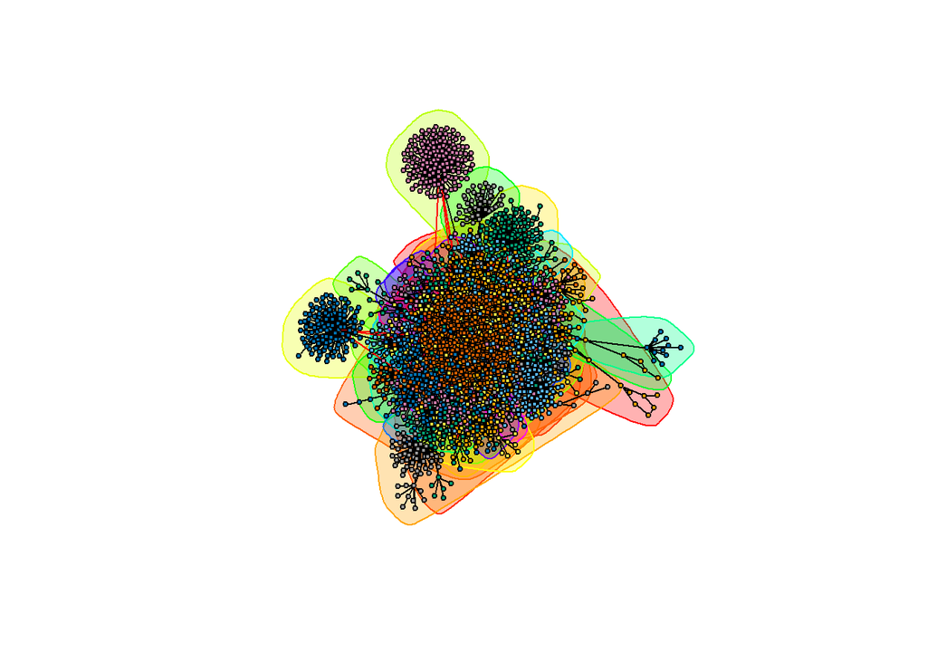

```r
plot(fast_greedy, g, layout = layout_with_lgl(g), vertex.label=NA, vertex.size=3)
```

Chi sono i membri della comunità più grande?

```r
library(tidyverse)

largest_community = as.tibble(data.frame(V(g)[which(membership(fast_greedy)==6)]$name))%>%
  rename(name = V.g..which.membership.fast_greedy.....6...name)


largest_community
```

```
## # A tibble: 612 x 1
##    name
##    <chr>
##  1 4 SHADOW TREE LANE MEMBER CORP.
##  2 40 WALL DEVELOPMENT ASSOCIATES LLC
##  3 401 MEZZ VENTURE LLC
##  4 401 NORTH WABASH VENTURE LLC
##  5 809 NORTH CANON MEMBER CORPORATION
##  6 AMBOY BANK
##  7 ARIZONA HOUSE OF REPRESENTATIVES
##  8 ASHLEY MARQUIS
##  9 BANK OF CHINA
## 10 BEDFORD HILLS CORP.
## # ... with 602 more rows
```

Di questa comunità chi sono i nodi più importanti?

```r
as.list(centralities)$nodes%>%
  inner_join(largest_community)%>%
  arrange(desc(pagerank))%>%
  select(-betweenness, -closeness)%>%
  head(5)
```

```
## # A tibble: 5 x 5
##      id name                      tipo         degree pagerank
##   <int> <chr>                     <chr>         <dbl>    <dbl>
## 1   211 DONALD J. TRUMP           Person          757 0.0903
## 2   207 DJT HOLDINGS LLC          Organization     36 0.00360
## 3  1036 TTTT VENTURE LLC          Organization      9 0.000956
## 4   626 OPO HOTEL MANAGER LLC     Organization      7 0.000862
## 5  1002 TRUMP OLD POST OFFICE LLC Organization      6 0.000740
```

Osserviamo che Donald Trump fa parte della comunità più grande ed è anche il nodo più importante di questa.

## Hierarchical Clustering

Un’altro metodo per raggruppare i nodi della rete è il **clustering gerarchico**, in cui bisogna definire una misura di dissomiglianza o di distanza tra i nodi. Inizialmente tutti i nodi formano un singolo gruppo di un nodo, dopo di che passo dopo passo si fondono in gruppi (cluster) sempre più grandi in base alle dissomiglianze/distanze più piccole tra i nodi fino a che si arriva ad avere un unico grande cluster che contiene tutti i nodi.

I passi del processo di clustering gerarchico vengono rappresentati in un **dendrogramma** con il quale è facile capire come si fondono i nodi della rete.

Vediamo come vengono raggruppati i nodi con il clustering gerarchico.

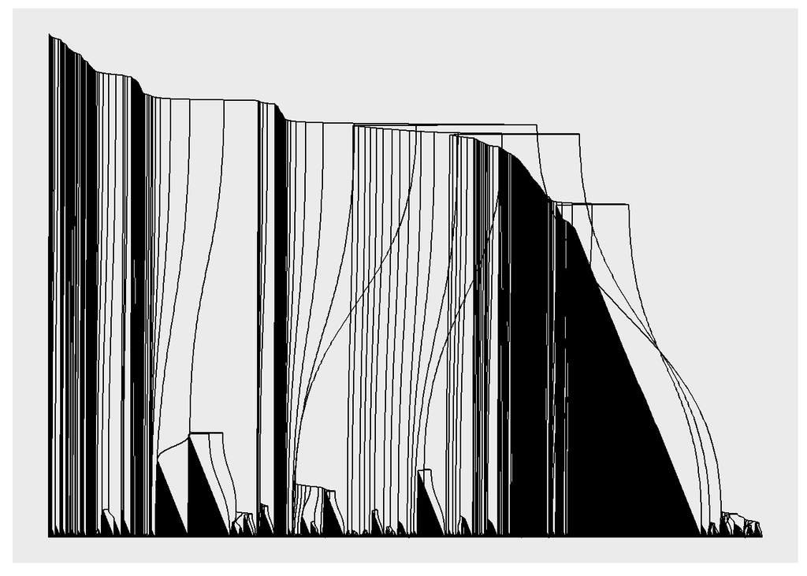

```r
# misura di dissomiglianza è 1 - S (dove S è la matrice delle somiglianze tra i nodi)
# distance matrix
D = 1 - S

# distanze tra i nodi
d = as.dist(D)

#clusterig gerarchico con metodo average-link
hc = hclust(d, method = "average")

# dendrogramma
ggraph(hc, layout="dendrogram")+
  geom_edge_diagonal()
```

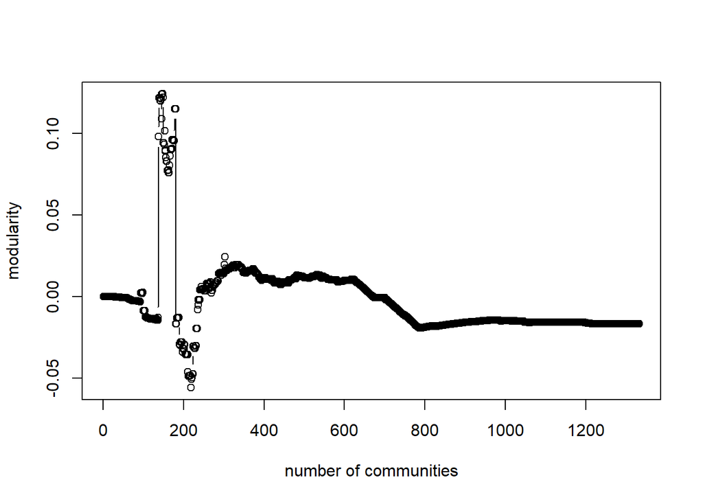

```r
# tagliamo il dendrogramma in diverse altezze
clusters_ = cutree(hc, k = 2:(vcount(g)/2))
# calcoliamo la modularità per ciascuna partizione
m = apply(clusters_, 2, FUN = function(x) {modularity(g, x)})
# tracciamo le modularità delle partizioni
plot(m, xlab = "number of communities", ylab = "modularity", type = "b")
```

Partizionando i nodi in quanti clusters si ottiene la modularità maggiore?

```r
# la partizione in clusters che da la maggiore modularità é in:
which.max(m)
```

```
## 149
## 148
```

Tracciamo la rete nello stato in cui ci sono 149 clusters, che è lo stato del processo di clustering gerarchico che da la modularità maggiore.

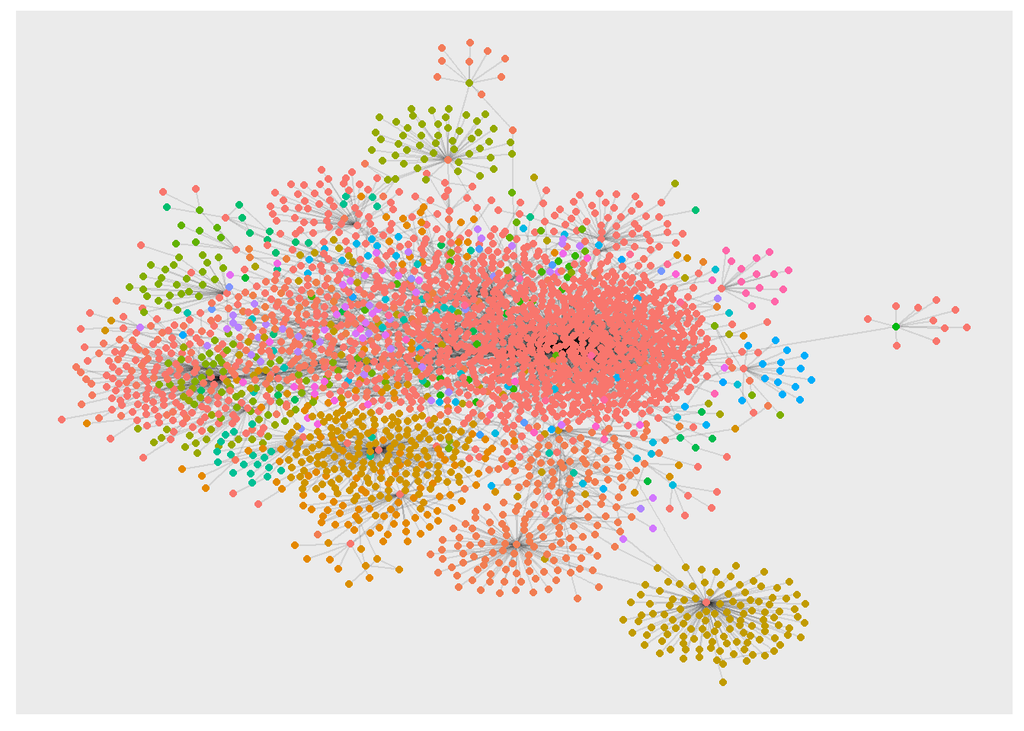

```r
library(ggraph)
clusters = as.factor(cutree(hc, k=149))

ggraph(g, layout="lgl")+
  geom_edge_link(alpha=0.1)+
  geom_node_point(aes(color=clusters), alpha = 1, show.legend = F)
```

notiamo che anche partizionando i nodi in 149 clusters la maggior parte dei nodi sono raggruppati in un unico grande cluster.

```r
sigma%>%
  arrange(desc(similarity))
```

```
## # A tibble: 334,305 x 5
##        x     y similarity name.x                       name.y
##    <int> <int>      <dbl> <chr>                        <chr>
##  1    53   144         1. ANGELA CHAO                  CHRISTINE CHAO
##  2   140   328         1. CHLOE MURDOCH                GRACE MURDOCH
##  3   176   286         1. DANIEL RIDLOFF               FELIX SATER
##  4   865   916         1. TIHT CHICAGO MEMBER ACQUISI~ TRUMP CHICAGO MANAGING M~
##  5   865   917         1. TIHT CHICAGO MEMBER ACQUISI~ TRUMP CHICAGO MEMBER LLC
##  6   916   917         1. TRUMP CHICAGO MANAGING MEMB~ TRUMP CHICAGO MEMBER LLC
##  7     7   308         1  4C INSIGHTS                  GCM GROSVENOR
##  8     7   614         1  4C INSIGHTS                  NORTH ASTOR STREET CONDO
##  9    11    19         1  ABE WALLACH                  ALAN GARTEN
## 10    11    49         1  ABE WALLACH                  ANDREW WEISS
## # ... with 334,295 more rows
```

Infatti notiamo che tra molti nodi esiste una somiglianza pari a 1 quindi la dissomiglianza, utilizzata come distanza in base alla quale i nodi si fondono nei cluster, per molti nodi è nulla. Quindi tutti questi nodi con somiglianza a 1 formano subito un grande cluster.

## Connectivity

Verifichiamo se la rete è una componente connessa, cioè se per ogni coppia di nodi esiste tra loro la relazione di equivalenza.

- Tra due nodi c’è una relazione di equivalenza se tra i due valgono le seguenti realzioni:
1. Riflessiva : for each $v \in V, vRv$
2. Simmetrica : for each $a,b \in V, aRb \to bRa$
3. Transitiva : for each $a,b,c \in V$, $aRb$ & $bRc \to aRc$

In altre parole se per ogni coppia di nodi di una partizione (sottografo), esiste almeno un cammino che li collega allora la partizione è una componente connessa. L’intero grafo può essere una componente connessa.

```r
g = graph_from_data_frame(edges, directed = FALSE, vertices = nodes$name)
c = components(g)
c$no
```

```
## [1] 1
```

```r
c$csize
```

```
## [1] 2669
```

Esiste solo una componente composta da tutti i 2669 nodi, quindi la rete è una componente connessa.

Analizziamo se ci sono **k-componenti** cioè sottoinsiemi di nodi in cui per ogni coppia di nodi esistono almeno k cammini **nodo-indipendenti**, cioè cammini che non hanno nessun nodo in comune aparte i nodi alle estremità dei cammini.

Una k-componente per definizione ha almeno k cammini nodo-indipendenti per ciascuna coppia di nodi, quindi per ciascuna coppia di nodi della k-componente esistono anche k-1 cammini nodo-indipendenti.

Quindi per $k\ge2$, una k-componente è nidificata in una (k-1)-componente.

Esiste una gerarchia tra le componenti nidificate, si parte dalle k-componenti con k più elevato (le foglie) e si risale fino ad arrivare alla componente più grande (la radice).

Per sconnettere una k-componente bisogna togliere da essa almeno k nodi.

Le k-componenti sono quindi un’indice di coesione e di connettività.

Quali sono i nodi che formano le componenti più coese?

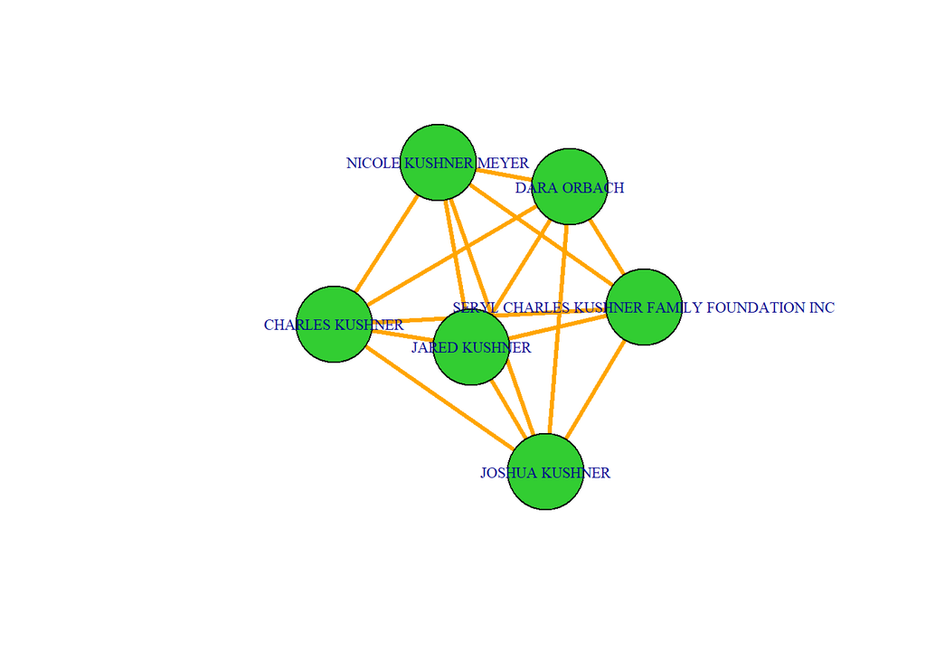

```r
# k-components gerarchia
b = cohesive_blocks(g)

# nodi delle componenti
bn = blocks(b)

# grafi delle componenti
bg = graphs_from_cohesive_blocks(b, g)

# tracciamo il grafo della componente più coesa cioè quella con k più elevato
co = cohesion(b)
h = bg[[which.max(co)]]
plot(h, layout=layout_with_lgl(h), vertex.size=50, vertex.color="limegreen", edge.color="orange", edge.width=3, vertex.label.cex=0.7)
```

Sappiamo che è una 5-componente quindi per sconnetterla bisogna rimuovere 5 nodi lasciando un solo nodo sconnesso.

Quali sono i nodi appartenenti a questa 5-componente?

```r
five_comp = data.frame(V(h)$name)%>%
  rename(name = V.h..name)%>%
  inner_join(nodes)

five_comp
```

```
##                                          name   id         tipo
## 1                             CHARLES KUSHNER  133       Person
## 2                                 DARA ORBACH  177       Person
## 3                               JARED KUSHNER  406       Person
## 4                              JOSHUA KUSHNER  447       Person
## 5                        NICOLE KUSHNER MEYER  607       Person
## 6 SERYL CHARLES KUSHNER FAMILY FOUNDATION INC 1266 Organization
```

Questi 6 nodi formano la componente più coesa. Le coppie di queste organizzazioni hanno almeno 5 cammini nodo-indipendenti che le collegano quindi hanno un’elevata connettività.

Sappiamo da b = cohesive_blocks(g) che c’è un’altra 5-componente formata anch’essa da 6 nodi, la B-314.

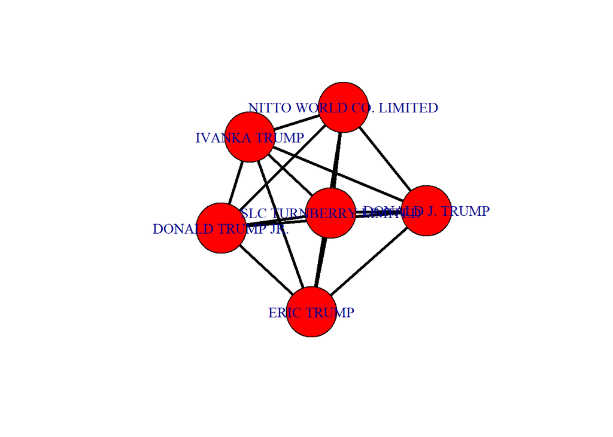

```r
k = bg[[314]]
plot(k, layout=layout_with_lgl(k), vertex.size=50, vertex.color="red", edge.color="black", edge.width=3,
     vertex.label.cex=1)
```

```r
five_comp1 = data.frame(V(k)$name)%>%
  rename(name = V.k..name)%>%
  inner_join(nodes)

five_comp1
```

```
##                      name   id         tipo
## 1         DONALD J. TRUMP  211       Person
## 2        DONALD TRUMP JR.  213       Person
## 3              ERIC TRUMP  276       Person
## 4            IVANKA TRUMP  388       Person
## 5   SLC TURNBERRY LIMITED  753 Organization
## 6 NITTO WORLD CO. LIMITED 1102 Organization
```

## Percolation

Il processo di percolazione sulle reti consiste nel rimuovere alcuni nodi dalla rete con l’obiettivo di comprendere in che modo la rimozione dei nodi influenza la rete.

Proviamo a togliere dalla rete i 5 nodi con il grado più alto.

```r
as.list(centralities)$nodes%>%
  arrange(desc(degree))%>%
  select(-betweenness, -closeness, - pagerank)%>%
  head(5)
```

```
## # A tibble: 5 x 4
##      id name                 tipo         degree
##   <int> <chr>                <chr>         <dbl>
## 1   211 DONALD J. TRUMP      Person          757
## 2  1075 WILBUR ROSS          Person          157
## 3   775 STEVEN MNUCHIN       Person          118
## 4   529 MAR-A-LAGO CLUB, INC Organization    110
## 5   857 THRIVE CAPITAL       Organization     87
```

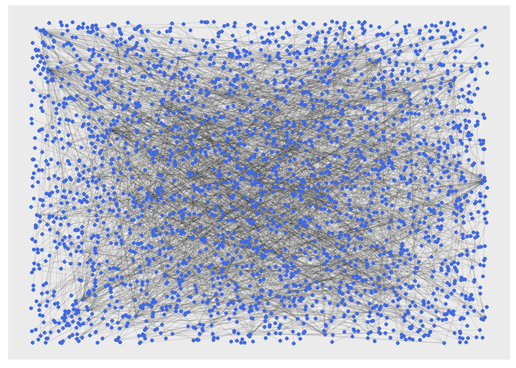

```r
d = degree(g)
names(d) = 1:length(d)
d = sort(d, decreasing = T)
del = as.integer(names(d[1:5]))
g2 = delete_vertices(g, del)

ggraph(g2, layout = "lgl")+
  geom_edge_link(alpha=0.1)+
  geom_node_point(color="royalblue")
```

Osserviamo che la rete senza i 5 nodi con grado più alto risulta essere molto sparsa e molto meno connessa.

La rete senza i 5 nodi con grado più alto è ancora una componente connessa?

```r
c = components(g2)
c$no
```

```
## [1] 802
```

No, vediamo che la rete non è più una componente, infatti si formano ben 802 componenti diverse.

Analizziamo come decresce la dimensione della componente più grande (gigante) facendo la percolazione con le varie strategie di rimozione dei nodi.

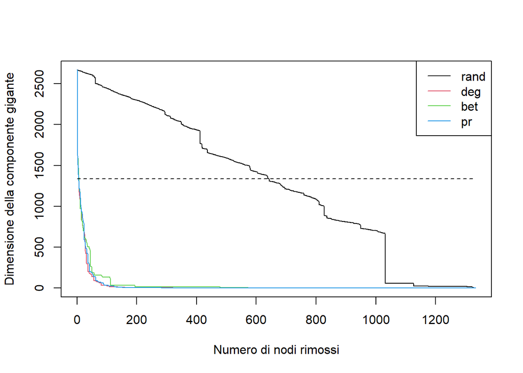

```r
#INPUT:
# g: grafo
# size : numero di nodi da rimuovere
# d : vettore con i nodi da rimuovere
#OUTPUT:
# giant : vettore con le dimensioni delle componenti giganti dopo ogni rimozione

percolate = function(g, size, d){

  giant = vector()

  #dimensione della componente iniziale
  c = components(g)
  giant[1] = max(c$csize)

  names(d) = 1:length(d)
  d = sort(d, decreasing = TRUE)
  vital = as.integer(names(d[1:size]))

  for(i in 1:size){
    c = components(delete_vertices(g, vital[1:i]))
    giant[i+1] = max(c$csize)
  }
  return(giant)
}

# resilienza (numero di nodi da rimuovere)
size = vcount(g)/2

# tolgo nodi a random
rand = percolate(g, size = size, d = sample(V(g), size))

# tolgo i nodi con grado più alto
deg = percolate(g, size = size, d = degree(g))

# tolgo i nodi con la betweenness centrality più alta
bet = percolate(g, size = size, d = betweenness(g))

# tolgo i nodi con la pagerank centrality più alta
pr = percolate(g, size = size, d = page_rank(g)$vector)

plot(0:size, rand, type = "l", col = 1, xlab = "Numero di nodi rimossi", ylab = "Dimensione della componente gigante")
lines(0:size, deg, col=2)
lines(0:size, bet, col=3)
lines(0:size, pr, col=4)
lines(0:size, rep(size, size+1), lty=2)
legend(x = "topright", legend = c("rand", "deg", "bet", "pr"), lty = 1, col=1:4, cex = 1)
```

Vediamo che togliendo nodi a caso la dimensione della componente gigante decresce lentamente. Bisogna rimuovere centinaia di nodi per far si che la dimensione della componente gigante sia più piccola della metà dei nodi della rete.

Invece, togliendo i nodi con le misure di centralità più alte la dimesione della componente gigante decresce molto rapidamente, basta rimuovere qualche nodo per far si che la dimensione della componente gigante sia più piccola della metà dei nodi della rete, e rimuovendo qualche decina di nodi la dimensione della componente gigante arriva vicino a 1.

Perciò rimuovendo pochi nodi con centralità elevata la rete cade a pezzi.

## Analisi di alcune proprietà delle reti

## Assortativity

Le persone hanno una forte tendenza ad associarsi con persone che percepiscono siano simili a se stessi.

Questa tendenza è chiamata **omofilia** o **mescolanza assortativa**.

Più raramente incontriamo la tendenza delle persone ad associarsi con altre persone che non sono simili a loro, questa tendenza è chiamata **eterofilia** o **mescolanza disassortativa**.

Una rete è assortativa quando gran parte dei legami è tra nodi dello stesso tipo o tra nodi con caratteristiche simili.

Calcoliamo la assortatività della rete con la modularità poiché i nodi appartengono a tre categorie diverse (caratteristiche enumerative) che sono: Person, Organization e Federal Agency.

```r
#creo un vettore che assegna i nodi alle rispettive categorie
library(igraph)
g = graph_from_data_frame(edges, directed = FALSE, vertices = nodes$name)

membership = nodes%>%
  mutate(category = ifelse(tipo == "Organization", 1, ifelse(tipo == "Person", 2, ifelse(tipo=="Federal Agency", 3, NA))))

membership = membership$category

V(g)$category = membership
mem = V(g)$category
names(mem) = V(g)$name

# calcolo la modularità
modularity(g, membership = mem)
```

```
## [1] -0.1599903
```

La assortività della rete è negativa quindi tra i nodi dello stesso tipo ci sono meno archi di quelli attesi dunque la rete è disassortativa, ovvero la maggior parte degli archi è tra nodi di tipo differente, quindi tra persone e organizzazioni.

Misuriamo anche la assortatività in base al grado dei nodi.

Il grado dei nodi è una caratteristica scalare, quindi la assortatività in base al grado va misurata con il coefficiente di correlazione di pearson tra le variabili L ed R.

In L ci sono i gradi dei nodi che sono le estremità degli archi from, to.

In R ci sono i gradi dei nodi che sono le estremità degli archi to, from.

La rete sarà assortativa se i nodi di alto grado sono maggiormente collegati con altri nodi di alto grado, e i nodi di grado basso con altri nodi di basso grado.

```r
g = graph_from_data_frame(edges, directed = FALSE, vertices = nodes$name)

d = degree(g)

edge = as_edgelist(g)

l = c(edge[,1], edge[,2])

r = c(edge[,2], edge[,1])

dl = d[l]
dr = d[r]

# coef di correlazione di pearson
cor(dl, dr, method = "pearson")
```

```
## [1] -0.168972
```

Risulta negativa quindi non è assortativa, è più disassortativa quindi ci sono più archi tra nodi con grado non simile.

## Small-World

Controlliamo se sulla rete si verifica l’effetto piccolo mondo (Small-World), ovvero se la distanza geodesica più frequente è sorprendentemente breve, soprattutto se confrontata con il numero di nodi della rete.

La distanza media rispecchia questo valore basso se non ci sono distanze anomale cioè distanze molto lunghe.

```r
g = graph_from_data_frame(edges, directed = FALSE, vertices = nodes$name)

# numero di nodi della rete
vcount(g)
```

```
## [1] 2669
```

```r
# distanza media
mean_distance(g)
```

```
## [1] 3.819304
```

```r
# diametro (distanza più lunga)
diameter(g)
```

```
## [1] 13
```

```r
# frequenze degli shortest paths con le varie lunghezze (distanze)
distance_table(g)
```

```
## $res
##  [1]    3380  332268 1100373 1302329  598433  162830   41009   15356    3785
## [10]     584      77      19       3
##
## $unconnected
## [1] 0
```

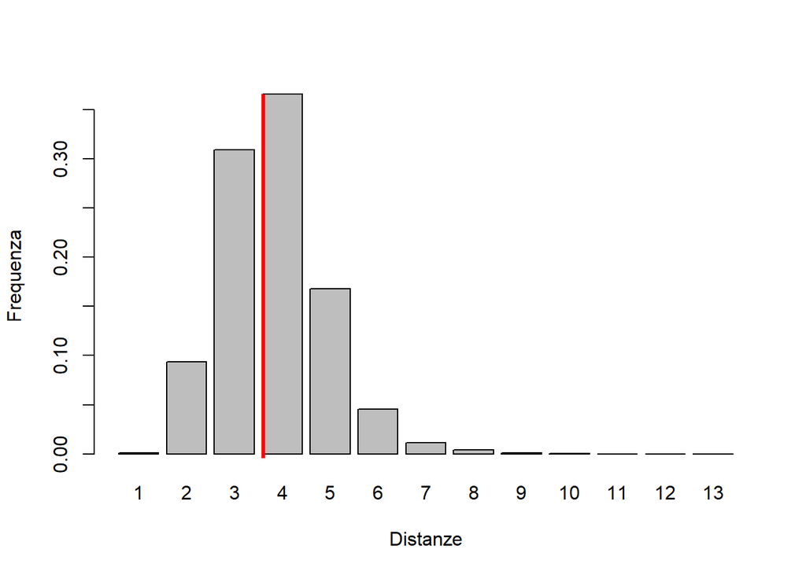

```r
paths = distance_table(g)$res

names(paths) = 1:length(paths)

barplot(paths/sum(paths), xlab="Distanze", ylab="Frequenza")
abline(v = mean_distance(g), col = "red", lwd = 3, lty = 1)
```

Osserviamo che la distanza media rispecchia il valore delle distanze più frequenti, ed è un valore molto basso soprattutto se confrontato ai 2669 nodi della rete. Quindi è una rete con l’effetto piccolo mondo.

## Degree Distribution

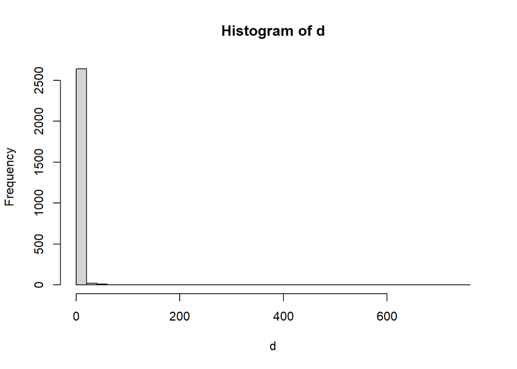

```r
d = degree(g)
hist(d, breaks = 30)
```

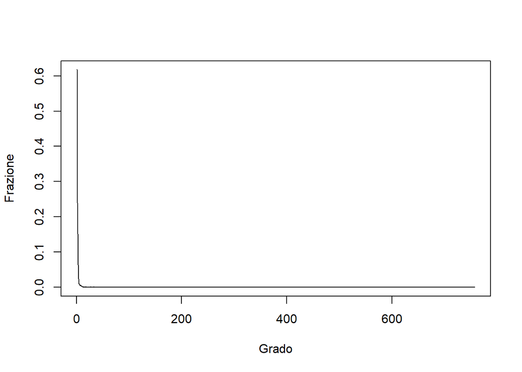

```r
d = degree(g)
z = degree_distribution(g)
plot(1:max(d), z[2:length(z)], type = "l", xlab="Grado", ylab="Frazione")
```

- Power Law :

$$P_k = Ck^{-\alpha}$$

Dove $k\ge0$, $P_k$ è la frazione dei nodi di grado $k$, $C$ è una costante e $\alpha$ è l’esponente della Power Law ed è $2\le\alpha\le3$

Se si fa il logaritmo in etrambi i membri si ottiene:

$$\log P_k = -\alpha \log k + \log C$$

che equivale all’equazione della retta in forma esplicita $y = mx + q$, quindi $-\alpha$ è la pendenza della retta e $\log C$ è il punto di intersezione della retta con l’asse delle ordinate.

Quindi $P_k = Ck^{-\alpha}$ in scala log-log è una retta con pendenza negativa.

Per verificare se una distribuzione dei gradi segue una Power Law controlliamo che il grafico della funzione delle frazioni dei nodi di grado k al variare di $k\ge0$ passato in scala log-log sia una retta.

Un’altro metodo per verificare se una distribuzione segue la Power Law è tracciare la funzione di distribuzione cumulativa (CCDF) su scala log-log.

- CCDF :

$$P_k = \sum_{x=k}^{\infty} P_x$$

dove $P_k$ è la frazione dei nodi che hanno grado $k$ o grado superiore.

Se $P_k = Ck^{-\alpha}$ e $\alpha> 1$, allora :

$$P_k = \sum_{x=k}^{\infty} P_x = C \sum_{x=k}^{\infty} x^{-\alpha} \sim= \frac{C}{\alpha - 1} k^{-(\alpha - 1)}$$

si ha quindi :

$$P_k \sim \frac{C}{\alpha - 1} k^{-(\alpha - 1)}$$

anche questa funzione se passata in scala log-log dovrebbe risulatare simile ad una retta.

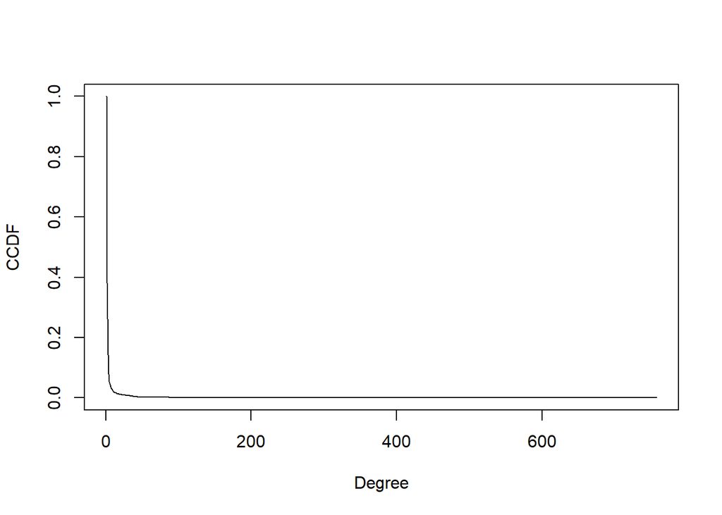

```r
# Cumulative distribution
ccdf = function(d) {
  n = length(d)
  max = max(d)
  p = rep(0, max)
  for (i in 1:length(p)) {
    p[i] = length(d[d >= i]) / n
  }
  return(p)
}

d = degree(g)

p = ccdf(d)

plot(1:max(d), p, type = "l", xlab="Degree", ylab="CCDF")
```

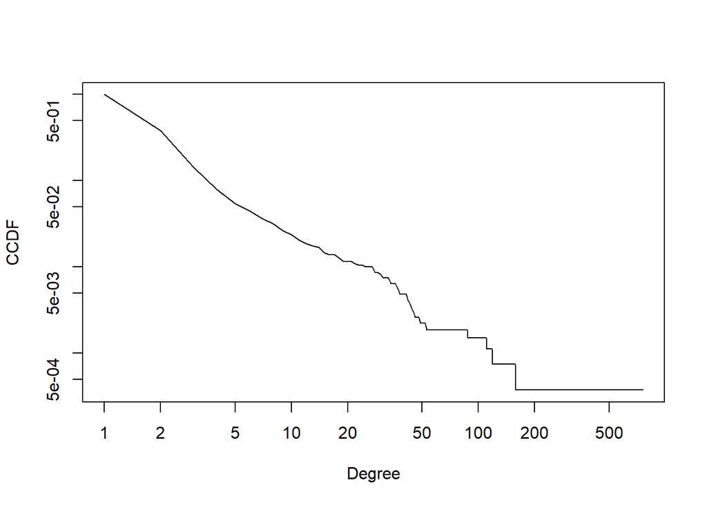

```r
# in scala log-log
plot(1:max(d), p, log="xy", type = "l", xlab="Degree", ylab="CCDF")
```

Quello che possiamo dire è che la rete ha una distribuzione dei gradi di tipo **long-tail**.

Perciò nella rete la stra grande maggioranza dei nodi ha un grado basso e pochi nodi hanno grado notevolmente elevato; questi nodi sono detti **hub**.

Chi sono gli hub nella rete?

```r
d[d>100]
```

```
##      DONALD J. TRUMP MAR-A-LAGO CLUB, INC       STEVEN MNUCHIN
##                  757                  110                  118
##          WILBUR ROSS
##                  157
```

Sono solo 4 i nodi con grado maggiore a 100, questi nodi sono gli hub.

## Risultati dalle ricerche sul web

Abbiamo trovato i nodi più centrali/importanti della rete, ovvero:

- WILBUR ROSS
- STEVEN MNUCHIN
- JARED KUSHNER
- MAR-A-LAGO CLUB, INC
- THRIVE CAPITAL

Chi sono queste persone e organizzazioni?

- **WILBUR ROSS**

Wilbur Louis Ross Jr. (Weehawken, 28 novembre 1937) è un politico statunitense, dal 2017 è il segretario al Commercio.

*Legami con Donald Trump*: Nel 2016 decide di aderire ai repubblicani per sostenere la campagna elettorale di Donald Trump.

A seguito della vittoria di Trump alle elezioni del 2016, Ross venne nominato da quest’ultimo come segretario al commercio e ottenne la carica il 27 febbraio 2017.

Fonte: https://it.wikipedia.org/wiki/Wilbur_Ross

- **STEVEN MNUCHIN**

Steven Terner “Steve” Mnuchin (New York, 21 dicembre 1962) è un banchiere, produttore cinematografico e politico statunitense, 77º ed attuale Segretario al tesoro degli Stati Uniti d’America.

*Legami con Donald Trump*: Mnuchin per anni ha donato ingenti somme di denaro per sostenere diverse campagne elettorali, sia di democratici che di repubblicani.

Mnuchin è uno dei primi a sostenere Trump nelle primarie repubblicane, tanto da venir poi nominato da questi responsabile finanziario della sua campagna con Lewis Eisenberg.

Il 30 novembre 2016 Trump annuncia ufficialmente che Mnuchin sarebbe stato il suo Segretario al Tesoro.

Fonte: https://it.wikipedia.org/wiki/Steven_Mnuchin

- **JARED KUSHNER**

Jared Kushner (Livingston, 10 gennaio 1981) è un imprenditore statunitense.

*Legami con Donald Trump*: Il 25 ottobre 2009 ha sposato Ivanka Trump, figlia di Donald e Ivana Trump, con cui ha tre figli.

Il 20 gennaio 2017 viene nominato assieme a Stephen Miller senior advisor del Presidente degli Stati Uniti d’America Donald Trump.

Nel marzo 2017 Trump lo ha messo a capo del neo-istituito Office of American Innovation (OAI) della Casa Bianca.

Fonte: https://it.wikipedia.org/wiki/Jared_Kushner

- **MAR-A-LAGO CLUB, INC**

Mar-a-Lago è un resort situato a Palm Beach, in Florida.

Il resort è stato costruito negli anni 1920 da Marjorie Merriweather Post come residenza invernale per i presidenti statunitensi.

Questo resort contiene il Mar-a-Lago Club, un club riservato ai soli membri con camere, un centro benessere e altri servizi in stile hotel.

Il club conta quasi 500 soci paganti e ammette dai venti ai quaranta nuovi soci all’anno. I membri includono il dirigente petrolifero Bill Koch , il finanziere Thomas Peterffy , il leader del Partito Democratico del New Jersey George Norcross , il lobbista Kenneth Duberstein , gli sviluppatori immobiliari Bruce E. Toll e Richard LeFrak , il dirigente dei media Christopher Ruddy , conduttore di talk show Howie Carr e il coach della NFL Bill Belichick .

*Legami con Donald Trump*: Nel dicembre 1985 venne acquistato dall’imprenditore Donald Trump.

Fonte: https://en.wikipedia.org/wiki/Mar-a-Lago

- **THRIVE CAPITAL**

Thrive Capital è una società di investimento di capitale di rischio focalizzata sugli investimenti in Internet e software.

*Legami con Donald Trump*: Il fondatore e socio amministratore della società Thrive Capital è Joshua Kushner, fratello di Jared Kushner, che come abbiamo scoperto sopra, è il genero e consigliere senior di Donald Trump.

Fonti: https://www.thrivecap.com/ e https://en.wikipedia.org/wiki/Joshua_Kushner

Oltre ai nodi principali della rete abbiamo trovato anche quali potrebbero essere i futuri collegamenti di Trump facendo il **link-prediction**, questi nodi sono:

- THE ERIC TRUMP FOUNDATION
- ANNIE DONALDSON
- JAMES BURNHAM
- DEUTSCHE BANK
- TITAN ATLAS MANUFACTURING
- **THE ERIC TRUMP FOUNDATION**

È una organizzazione benefica il cui presidente e fondatore è Eric Trump, figlio di Donald Trump e la sua prima moglie Ivana Trump.

Attualmente la fondazione ha interrotto la raccolta fondi per evitare l’affermazione di qualsiasi improprietà e/o un conflitto di interessi per via dell’auttuale carica di presidente degli Stati Uniti del padre del fondatore.

Fonti: https://www.erictrumpfoundation.com/ e https://en.wikipedia.org/wiki/Eric_Trump

- **ANNIE DONALDSON**

È una avvocatessa Americana. Donaldson è entrata alla Casa Bianca nel febbraio 2017, in qualità di vice consigliere del presidente Trump.

Ha lasciato l’incarico nel dicembre 2018.

Fonte: https://en.wikipedia.org/wiki/Annie_Donaldson

- **DEUTSCHE BANK**

È una banca d’investimento multinazionale e una società di servizi finanziari con sede a Francoforte, in Germania.

- **TITAN ATLAS MANUFACTURING**

Titan Atlas Manufacturing, un’azienda specializzata in prodotti per l’edilizia, ha funzionato per appena due anni e ha chiuso nel 2012, lasciando una scia di fatture non pagate e tasse non pagate.

Abbiamo anche trovato le due componenti più coese della rete, la prima è composta da:

- CHARLES KUSHNER
- DARA ORBACH
- JARED KUSHNER
- JOSHUA KUSHNER
- NICOLE KUSHNER MEYER
- SERYL CHARLES KUSHNER FAMILY FOUNDATION INC

**Joshua e Jared Kushner** già li conosciamo. **Charles Kushner** è il loro padre ed è uno sviluppatore immobiliare fondatore della Kushner Companies.

**Nicole Kushner Meyer** è sorella di Joshua e Jared e fa parte della Kushner Companies.

**Dara Kushner Orbach** è sorella di Joshua e Jared.

**Seryl Charles Kushner family foundation inc.**

Charles Kushner, sua moglie Seryl e la sua famiglia trasferiscono la loro filantropia attraverso la Charles and Seryl Kushner Charitable Foundation.

I Kushner sono forti sostenitori delle istituzioni ebraiche negli Stati Uniti e in Israele.

Le aree di finanziamento sono: cause ebraiche, istruzione, salute e servizi umani.

Fonte: https://www.insidephilanthropy.com/real-estate-givers/charles-and-seryl-kushner

La seconda componente più coesa è composta da:

- DONALD J. TRUMP
- DONALD TRUMP JR.
- ERIC TRUMP
- IVANKA TRUMP
- SLC TURNBERRY LIMITED
- NITTO WORLD CO. LIMITED

I primi 4 sono Donald Trump e i suoi 3 figli avuti con la sua prima moglie Ivana Trump.

**SLC TURNBERRY LIMITED** è una società di ospitalità con sede nel Regno Unito.

```r
edges%>%
  filter(((from == "DONALD J. TRUMP")&(to == "SLC TURNBERRY LIMITED"))|((from == "SLC TURNBERRY LIMITED")&(to == "DONALD J. TRUMP")))
```

```
## # A tibble: 1 x 3
##   from            to                    Connection
##   <chr>           <chr>                 <chr>
## 1 DONALD J. TRUMP SLC TURNBERRY LIMITED Chairman (as of 2016 FEC filing)
```

Trump ne è il Chairman.

**NITTO WORLD CO. LIMITED**

Nitto World Co., Ltd è stata fondata nel 1987. La linea di business dell’azienda comprende la gestione di hotel e motel pubblici.

```r
edges%>%
  filter(((from == "DONALD J. TRUMP")&(to == "NITTO WORLD CO. LIMITED"))|((from == "NITTO WORLD CO. LIMITED")&(to == "DONALD J. TRUMP")))
```

```
## # A tibble: 1 x 3
##   from            to                      Connection
##   <chr>           <chr>                   <chr>
## 1 DONALD J. TRUMP NITTO WORLD CO. LIMITED Director (as of 2016 FEC filing)
```

Trump ne è il direttore.